# House Prices - Advanced Regression Techniques

load the required packages first

```r
library(mlr,quietly = TRUE)
library(dplyr,quietly = TRUE)
library(ggplot2,quietly = TRUE)
library(caret,quietly = TRUE)
library(purrr,quietly = TRUE)
library(data.table,quietly = TRUE,warn.conflicts = FALSE)
library(readr,quietly = TRUE,warn.conflicts = FALSE)
```

Load the test and train datasets

```r
train=read_csv("train.csv")
test=read_csv("test.csv")
```

Rbind the two datasets to perform feature engineering, will later separate the two datasets again. Remove the variable Sale Price from the training set

```r
SalePrice=train$SalePrice
train$SalePrice=NULL
train_test=rbind(train,test)
```

Find the str of the combined train_test dataset. Also take the summary

```r
str(train_test)
```

```
Classes ‘tbl_df’, ‘tbl’ and 'data.frame':   2919 obs. of  80 variables:
 $ Id           : int  1 2 3 4 5 6 7 8 9 10 ...
 $ MSSubClass   : int  60 20 60 70 60 50 20 60 50 190 ...
 $ MSZoning     : chr  "RL" "RL" "RL" "RL" ...
 $ LotFrontage  : int  65 80 68 60 84 85 75 NA 51 50 ...
 $ LotArea      : int  8450 9600 11250 9550 14260 14115 10084 10382 6120 7420 ...
 $ Street       : chr  "Pave" "Pave" "Pave" "Pave" ...
 $ Alley        : chr  NA NA NA NA ...
 $ LotShape     : chr  "Reg" "Reg" "IR1" "IR1" ...
 $ LandContour  : chr  "Lvl" "Lvl" "Lvl" "Lvl" ...
 $ Utilities    : chr  "AllPub" "AllPub" "AllPub" "AllPub" ...
 $ LotConfig    : chr  "Inside" "FR2" "Inside" "Corner" ...
 $ LandSlope    : chr  "Gtl" "Gtl" "Gtl" "Gtl" ...
 $ Neighborhood : chr  "CollgCr" "Veenker" "CollgCr" "Crawfor" ...
 $ Condition1   : chr  "Norm" "Feedr" "Norm" "Norm" ...
 $ Condition2   : chr  "Norm" "Norm" "Norm" "Norm" ...
 $ BldgType     : chr  "1Fam" "1Fam" "1Fam" "1Fam" ...
 $ HouseStyle   : chr  "2Story" "1Story" "2Story" "2Story" ...
 $ OverallQual  : int  7 6 7 7 8 5 8 7 7 5 ...
 $ OverallCond  : int  5 8 5 5 5 5 5 6 5 6 ...
 $ YearBuilt    : int  2003 1976 2001 1915 2000 1993 2004 1973 1931 1939 ...
 $ YearRemodAdd : int  2003 1976 2002 1970 2000 1995 2005 1973 1950 1950 ...
 $ RoofStyle    : chr  "Gable" "Gable" "Gable" "Gable" ...
 $ RoofMatl     : chr  "CompShg" "CompShg" "CompShg" "CompShg" ...
 $ Exterior1st  : chr  "VinylSd" "MetalSd" "VinylSd" "Wd Sdng" ...
 $ Exterior2nd  : chr  "VinylSd" "MetalSd" "VinylSd" "Wd Shng" ...
 $ MasVnrType   : chr  "BrkFace" "None" "BrkFace" "None" ...
 $ MasVnrArea   : int  196 0 162 0 350 0 186 240 0 0 ...
 $ ExterQual    : chr  "Gd" "TA" "Gd" "TA" ...
 $ ExterCond    : chr  "TA" "TA" "TA" "TA" ...
 $ Foundation   : chr  "PConc" "CBlock" "PConc" "BrkTil" ...
 $ BsmtQual     : chr  "Gd" "Gd" "Gd" "TA" ...
 $ BsmtCond     : chr  "TA" "TA" "TA" "Gd" ...
 $ BsmtExposure : chr  "No" "Gd" "Mn" "No" ...
 $ BsmtFinType1 : chr  "GLQ" "ALQ" "GLQ" "ALQ" ...
 $ BsmtFinSF1   : int  706 978 486 216 655 732 1369 859 0 851 ...
 $ BsmtFinType2 : chr  "Unf" "Unf" "Unf" "Unf" ...
 $ BsmtFinSF2   : int  0 0 0 0 0 0 0 32 0 0 ...
 $ BsmtUnfSF    : int  150 284 434 540 490 64 317 216 952 140 ...
 $ TotalBsmtSF  : int  856 1262 920 756 1145 796 1686 1107 952 991 ...
```

[output cut: 193 more lines]

```
  .. ..$ MiscVal      : list()
  .. .. ..- attr(*, "class")= chr  "collector_integer" "collector"
  .. ..$ MoSold       : list()
  .. .. ..- attr(*, "class")= chr  "collector_integer" "collector"
  .. ..$ YrSold       : list()
  .. .. ..- attr(*, "class")= chr  "collector_integer" "collector"
  .. ..$ SaleType     : list()
  .. .. ..- attr(*, "class")= chr  "collector_character" "collector"
  .. ..$ SaleCondition: list()
  .. .. ..- attr(*, "class")= chr  "collector_character" "collector"
  .. ..$ SalePrice    : list()
  .. .. ..- attr(*, "class")= chr  "collector_integer" "collector"
  ..$ default: list()
  .. ..- attr(*, "class")= chr  "collector_guess" "collector"
  ..- attr(*, "class")= chr "col_spec"
```

```r
summary(train_test)
```

```
       Id           MSSubClass       MSZoning          LotFrontage        LotArea          Street
 Min.   :   1.0   Min.   : 20.00   Length:2919        Min.   : 21.00   Min.   :  1300   Length:2919
 1st Qu.: 730.5   1st Qu.: 20.00   Class :character   1st Qu.: 59.00   1st Qu.:  7478   Class :character
 Median :1460.0   Median : 50.00   Mode  :character   Median : 68.00   Median :  9453   Mode  :character
 Mean   :1460.0   Mean   : 57.14                      Mean   : 69.31   Mean   : 10168
 3rd Qu.:2189.5   3rd Qu.: 70.00                      3rd Qu.: 80.00   3rd Qu.: 11570
 Max.   :2919.0   Max.   :190.00                      Max.   :313.00   Max.   :215245
                                                      NA's   :486
    Alley             LotShape         LandContour         Utilities          LotConfig
 Length:2919        Length:2919        Length:2919        Length:2919        Length:2919
 Class :character   Class :character   Class :character   Class :character   Class :character
 Mode  :character   Mode  :character   Mode  :character   Mode  :character   Mode  :character




  LandSlope         Neighborhood        Condition1         Condition2          BldgType
 Length:2919        Length:2919        Length:2919        Length:2919        Length:2919
 Class :character   Class :character   Class :character   Class :character   Class :character
 Mode  :character   Mode  :character   Mode  :character   Mode  :character   Mode  :character




  HouseStyle         OverallQual      OverallCond      YearBuilt     YearRemodAdd   RoofStyle
 Length:2919        Min.   : 1.000   Min.   :1.000   Min.   :1872   Min.   :1950   Length:2919
 Class :character   1st Qu.: 5.000   1st Qu.:5.000   1st Qu.:1954   1st Qu.:1965   Class :character
 Mode  :character   Median : 6.000   Median :5.000   Median :1973   Median :1993   Mode  :character
                    Mean   : 6.089   Mean   :5.565   Mean   :1971   Mean   :1984
                    3rd Qu.: 7.000   3rd Qu.:6.000   3rd Qu.:2001   3rd Qu.:2004
                    Max.   :10.000   Max.   :9.000   Max.   :2010   Max.   :2010

   RoofMatl         Exterior1st        Exterior2nd         MasVnrType          MasVnrArea      ExterQual
 Length:2919        Length:2919        Length:2919        Length:2919        Min.   :   0.0   Length:2919
 Class :character   Class :character   Class :character   Class :character   1st Qu.:   0.0   Class :character
 Mode  :character   Mode  :character   Mode  :character   Mode  :character   Median :   0.0   Mode  :character
                                                                             Mean   : 102.2
                                                                             3rd Qu.: 164.0
                                                                             Max.   :1600.0
                                                                             NA's   :23
```

[output cut: 56 more lines]

```
   3SsnPorch        ScreenPorch        PoolArea          PoolQC             Fence           MiscFeature
 Min.   :  0.000   Min.   :  0.00   Min.   :  0.000   Length:2919        Length:2919        Length:2919
 1st Qu.:  0.000   1st Qu.:  0.00   1st Qu.:  0.000   Class :character   Class :character   Class :character
 Median :  0.000   Median :  0.00   Median :  0.000   Mode  :character   Mode  :character   Mode  :character
 Mean   :  2.602   Mean   : 16.06   Mean   :  2.252
 3rd Qu.:  0.000   3rd Qu.:  0.00   3rd Qu.:  0.000
 Max.   :508.000   Max.   :576.00   Max.   :800.000

    MiscVal             MoSold           YrSold       SaleType         SaleCondition
 Min.   :    0.00   Min.   : 1.000   Min.   :2006   Length:2919        Length:2919
 1st Qu.:    0.00   1st Qu.: 4.000   1st Qu.:2007   Class :character   Class :character
 Median :    0.00   Median : 6.000   Median :2008   Mode  :character   Mode  :character
 Mean   :   50.83   Mean   : 6.213   Mean   :2008
 3rd Qu.:    0.00   3rd Qu.: 8.000   3rd Qu.:2009
 Max.   :17000.00   Max.   :12.000   Max.   :2010
```

Take all ‘Character’ class types and convert to factor (categorical) types

```r
trn_tst_chr=train_test %>%
  select_if(is.character) %>%
  mutate_each(funs(as.factor))
str(trn_tst_chr)
```

```
Classes ‘tbl_df’, ‘tbl’ and 'data.frame':   2919 obs. of  43 variables:
 $ MSZoning     : Factor w/ 5 levels "C (all)","FV",..: 4 4 4 4 4 4 4 4 5 4 ...
 $ Street       : Factor w/ 2 levels "Grvl","Pave": 2 2 2 2 2 2 2 2 2 2 ...
 $ Alley        : Factor w/ 2 levels "Grvl","Pave": NA NA NA NA NA NA NA NA NA NA ...
 $ LotShape     : Factor w/ 4 levels "IR1","IR2","IR3",..: 4 4 1 1 1 1 4 1 4 4 ...
 $ LandContour  : Factor w/ 4 levels "Bnk","HLS","Low",..: 4 4 4 4 4 4 4 4 4 4 ...
 $ Utilities    : Factor w/ 2 levels "AllPub","NoSeWa": 1 1 1 1 1 1 1 1 1 1 ...
 $ LotConfig    : Factor w/ 5 levels "Corner","CulDSac",..: 5 3 5 1 3 5 5 1 5 1 ...
 $ LandSlope    : Factor w/ 3 levels "Gtl","Mod","Sev": 1 1 1 1 1 1 1 1 1 1 ...
 $ Neighborhood : Factor w/ 25 levels "Blmngtn","Blueste",..: 6 25 6 7 14 12 21 17 18 4 ...
 $ Condition1   : Factor w/ 9 levels "Artery","Feedr",..: 3 2 3 3 3 3 3 5 1 1 ...
 $ Condition2   : Factor w/ 8 levels "Artery","Feedr",..: 3 3 3 3 3 3 3 3 3 1 ...
 $ BldgType     : Factor w/ 5 levels "1Fam","2fmCon",..: 1 1 1 1 1 1 1 1 1 2 ...
 $ HouseStyle   : Factor w/ 8 levels "1.5Fin","1.5Unf",..: 6 3 6 6 6 1 3 6 1 2 ...
 $ RoofStyle    : Factor w/ 6 levels "Flat","Gable",..: 2 2 2 2 2 2 2 2 2 2 ...
```

[output cut: 29 more lines]

find the number of NAs in each of the factor variables

```r
colSums(sapply(trn_tst_chr,is.na))
```

```
     MSZoning        Street         Alley      LotShape   LandContour     Utilities     LotConfig     LandSlope
            4             0          2721             0             0             2             0             0
 Neighborhood    Condition1    Condition2      BldgType    HouseStyle     RoofStyle      RoofMatl   Exterior1st
            0             0             0             0             0             0             0             1
  Exterior2nd    MasVnrType     ExterQual     ExterCond    Foundation      BsmtQual      BsmtCond  BsmtExposure
            1            24             0             0             0            81            82            82
 BsmtFinType1  BsmtFinType2       Heating     HeatingQC    CentralAir    Electrical   KitchenQual    Functional
           79            80             0             0             0             1             1             2
  FireplaceQu    GarageType  GarageFinish    GarageQual    GarageCond    PavedDrive        PoolQC         Fence
         1420           157           159           159           159             0          2909          2348
  MiscFeature      SaleType SaleCondition
         2814             1             0
```

Variables Alley, FireplaceQu, PoolQC, Fence, MiscFeature have very high NAs and are removed

```r
trn_tst_chr$Alley=NULL
trn_tst_chr$FireplaceQu=NULL
trn_tst_chr$PoolQC=NULL
trn_tst_chr$Fence=NULL
trn_tst_chr$MiscFeature=NULL
# rerun the command for finding total NAs in the factor variables
colSums(sapply(trn_tst_chr,is.na))
```

```
     MSZoning        Street      LotShape   LandContour     Utilities     LotConfig     LandSlope  Neighborhood
            4             0             0             0             2             0             0             0
   Condition1    Condition2      BldgType    HouseStyle     RoofStyle      RoofMatl   Exterior1st   Exterior2nd
            0             0             0             0             0             0             1             1
   MasVnrType     ExterQual     ExterCond    Foundation      BsmtQual      BsmtCond  BsmtExposure  BsmtFinType1
           24             0             0             0            81            82            82            79
 BsmtFinType2       Heating     HeatingQC    CentralAir    Electrical   KitchenQual    Functional    GarageType
           80             0             0             0             1             1             2           157
 GarageFinish    GarageQual    GarageCond    PavedDrive      SaleType SaleCondition
          159           159           159             0             1             0
```

Perform imputation of missing factor levels using mode. Use ‘Impute’ function from mlr package

```r
imp_fctr=impute(trn_tst_chr,classes = list(factor=imputeMode()))
colSums(sapply(imp_fctr$data,is.na))
```

```
     MSZoning        Street      LotShape   LandContour     Utilities     LotConfig     LandSlope  Neighborhood
            0             0             0             0             0             0             0             0
   Condition1    Condition2      BldgType    HouseStyle     RoofStyle      RoofMatl   Exterior1st   Exterior2nd
            0             0             0             0             0             0             0             0
   MasVnrType     ExterQual     ExterCond    Foundation      BsmtQual      BsmtCond  BsmtExposure  BsmtFinType1
            0             0             0             0             0             0             0             0
 BsmtFinType2       Heating     HeatingQC    CentralAir    Electrical   KitchenQual    Functional    GarageType
            0             0             0             0             0             0             0             0
 GarageFinish    GarageQual    GarageCond    PavedDrive      SaleType SaleCondition
            0             0             0             0             0             0
```

```r
trn_tst_chr=imp_fctr$data
head(trn_tst_chr,10)
```

|  | MSZoning | Street | LotShape | LandContour | Utilities | LotConfig | LandSlope | Neighborhood | Condition1 | Condition2 | BldgType | HouseStyle | RoofStyle | RoofMatl | Exterior1st | Exterior2nd | MasVnrType | ExterQual | ExterCond | Foundation | BsmtQual | BsmtCond | BsmtExposure | BsmtFinType1 | BsmtFinType2 | Heating | HeatingQC | CentralAir | Electrical | … |
| --- | --- | --- | --- | --- | --- | --- | --- | --- | --- | --- | --- | --- | --- | --- | --- | --- | --- | --- | --- | --- | --- | --- | --- | --- | --- | --- | --- | --- | --- | --- |
| 1 | RL | Pave | Reg | Lvl | AllPub | Inside | Gtl | CollgCr | Norm | Norm | 1Fam | 2Story | Gable | CompShg | VinylSd | VinylSd | BrkFace | Gd | TA | PConc | Gd | TA | No | GLQ | Unf | GasA | Ex | Y | SBrkr | … |
| 2 | RL | Pave | Reg | Lvl | AllPub | FR2 | Gtl | Veenker | Feedr | Norm | 1Fam | 1Story | Gable | CompShg | MetalSd | MetalSd | None | TA | TA | CBlock | Gd | TA | Gd | ALQ | Unf | GasA | Ex | Y | SBrkr | … |
| 3 | RL | Pave | IR1 | Lvl | AllPub | Inside | Gtl | CollgCr | Norm | Norm | 1Fam | 2Story | Gable | CompShg | VinylSd | VinylSd | BrkFace | Gd | TA | PConc | Gd | TA | Mn | GLQ | Unf | GasA | Ex | Y | SBrkr | … |
| 4 | RL | Pave | IR1 | Lvl | AllPub | Corner | Gtl | Crawfor | Norm | Norm | 1Fam | 2Story | Gable | CompShg | Wd Sdng | Wd Shng | None | TA | TA | BrkTil | TA | Gd | No | ALQ | Unf | GasA | Gd | Y | SBrkr | … |
| 5 | RL | Pave | IR1 | Lvl | AllPub | FR2 | Gtl | NoRidge | Norm | Norm | 1Fam | 2Story | Gable | CompShg | VinylSd | VinylSd | BrkFace | Gd | TA | PConc | Gd | TA | Av | GLQ | Unf | GasA | Ex | Y | SBrkr | … |
| 6 | RL | Pave | IR1 | Lvl | AllPub | Inside | Gtl | Mitchel | Norm | Norm | 1Fam | 1.5Fin | Gable | CompShg | VinylSd | VinylSd | None | TA | TA | Wood | Gd | TA | No | GLQ | Unf | GasA | Ex | Y | SBrkr | … |
| 7 | RL | Pave | Reg | Lvl | AllPub | Inside | Gtl | Somerst | Norm | Norm | 1Fam | 1Story | Gable | CompShg | VinylSd | VinylSd | Stone | Gd | TA | PConc | Ex | TA | Av | GLQ | Unf | GasA | Ex | Y | SBrkr | … |
| 8 | RL | Pave | IR1 | Lvl | AllPub | Corner | Gtl | NWAmes | PosN | Norm | 1Fam | 2Story | Gable | CompShg | HdBoard | HdBoard | Stone | TA | TA | CBlock | Gd | TA | Mn | ALQ | BLQ | GasA | Ex | Y | SBrkr | … |
| 9 | RM | Pave | Reg | Lvl | AllPub | Inside | Gtl | OldTown | Artery | Norm | 1Fam | 1.5Fin | Gable | CompShg | BrkFace | Wd Shng | None | TA | TA | BrkTil | TA | TA | No | Unf | Unf | GasA | Gd | Y | FuseF | … |
| 10 | RL | Pave | Reg | Lvl | AllPub | Corner | Gtl | BrkSide | Artery | Artery | 2fmCon | 1.5Unf | Gable | CompShg | MetalSd | MetalSd | None | TA | TA | BrkTil | TA | TA | No | GLQ | Unf | GasA | Ex | Y | SBrkr | … |

```r
str(trn_tst_chr)
```

```
'data.frame':   2919 obs. of  38 variables:
 $ MSZoning     : Factor w/ 5 levels "C (all)","FV",..: 4 4 4 4 4 4 4 4 5 4 ...
 $ Street       : Factor w/ 2 levels "Grvl","Pave": 2 2 2 2 2 2 2 2 2 2 ...
 $ LotShape     : Factor w/ 4 levels "IR1","IR2","IR3",..: 4 4 1 1 1 1 4 1 4 4 ...
 $ LandContour  : Factor w/ 4 levels "Bnk","HLS","Low",..: 4 4 4 4 4 4 4 4 4 4 ...
 $ Utilities    : Factor w/ 2 levels "AllPub","NoSeWa": 1 1 1 1 1 1 1 1 1 1 ...
 $ LotConfig    : Factor w/ 5 levels "Corner","CulDSac",..: 5 3 5 1 3 5 5 1 5 1 ...
 $ LandSlope    : Factor w/ 3 levels "Gtl","Mod","Sev": 1 1 1 1 1 1 1 1 1 1 ...
 $ Neighborhood : Factor w/ 25 levels "Blmngtn","Blueste",..: 6 25 6 7 14 12 21 17 18 4 ...
 $ Condition1   : Factor w/ 9 levels "Artery","Feedr",..: 3 2 3 3 3 3 3 5 1 1 ...
 $ Condition2   : Factor w/ 8 levels "Artery","Feedr",..: 3 3 3 3 3 3 3 3 3 1 ...
 $ BldgType     : Factor w/ 5 levels "1Fam","2fmCon",..: 1 1 1 1 1 1 1 1 1 2 ...
 $ HouseStyle   : Factor w/ 8 levels "1.5Fin","1.5Unf",..: 6 3 6 6 6 1 3 6 1 2 ...
 $ RoofStyle    : Factor w/ 6 levels "Flat","Gable",..: 2 2 2 2 2 2 2 2 2 2 ...
 $ RoofMatl     : Factor w/ 8 levels "ClyTile","CompShg",..: 2 2 2 2 2 2 2 2 2 2 ...
```

[output cut: 24 more lines]

```r
#no missing values now
```

Take all numerics variables separately

```r
str(train_test)
```

```
Classes ‘tbl_df’, ‘tbl’ and 'data.frame':   2919 obs. of  80 variables:
 $ Id           : int  1 2 3 4 5 6 7 8 9 10 ...
 $ MSSubClass   : int  60 20 60 70 60 50 20 60 50 190 ...
 $ MSZoning     : chr  "RL" "RL" "RL" "RL" ...
 $ LotFrontage  : int  65 80 68 60 84 85 75 NA 51 50 ...
 $ LotArea      : int  8450 9600 11250 9550 14260 14115 10084 10382 6120 7420 ...
 $ Street       : chr  "Pave" "Pave" "Pave" "Pave" ...
 $ Alley        : chr  NA NA NA NA ...
 $ LotShape     : chr  "Reg" "Reg" "IR1" "IR1" ...
 $ LandContour  : chr  "Lvl" "Lvl" "Lvl" "Lvl" ...
 $ Utilities    : chr  "AllPub" "AllPub" "AllPub" "AllPub" ...
 $ LotConfig    : chr  "Inside" "FR2" "Inside" "Corner" ...
 $ LandSlope    : chr  "Gtl" "Gtl" "Gtl" "Gtl" ...
 $ Neighborhood : chr  "CollgCr" "Veenker" "CollgCr" "Crawfor" ...
 $ Condition1   : chr  "Norm" "Feedr" "Norm" "Norm" ...
 $ Condition2   : chr  "Norm" "Norm" "Norm" "Norm" ...
 $ BldgType     : chr  "1Fam" "1Fam" "1Fam" "1Fam" ...
 $ HouseStyle   : chr  "2Story" "1Story" "2Story" "2Story" ...
 $ OverallQual  : int  7 6 7 7 8 5 8 7 7 5 ...
 $ OverallCond  : int  5 8 5 5 5 5 5 6 5 6 ...
 $ YearBuilt    : int  2003 1976 2001 1915 2000 1993 2004 1973 1931 1939 ...
 $ YearRemodAdd : int  2003 1976 2002 1970 2000 1995 2005 1973 1950 1950 ...
 $ RoofStyle    : chr  "Gable" "Gable" "Gable" "Gable" ...
 $ RoofMatl     : chr  "CompShg" "CompShg" "CompShg" "CompShg" ...
 $ Exterior1st  : chr  "VinylSd" "MetalSd" "VinylSd" "Wd Sdng" ...
 $ Exterior2nd  : chr  "VinylSd" "MetalSd" "VinylSd" "Wd Shng" ...
 $ MasVnrType   : chr  "BrkFace" "None" "BrkFace" "None" ...
 $ MasVnrArea   : int  196 0 162 0 350 0 186 240 0 0 ...
 $ ExterQual    : chr  "Gd" "TA" "Gd" "TA" ...
 $ ExterCond    : chr  "TA" "TA" "TA" "TA" ...
 $ Foundation   : chr  "PConc" "CBlock" "PConc" "BrkTil" ...
 $ BsmtQual     : chr  "Gd" "Gd" "Gd" "TA" ...
 $ BsmtCond     : chr  "TA" "TA" "TA" "Gd" ...
 $ BsmtExposure : chr  "No" "Gd" "Mn" "No" ...
 $ BsmtFinType1 : chr  "GLQ" "ALQ" "GLQ" "ALQ" ...
 $ BsmtFinSF1   : int  706 978 486 216 655 732 1369 859 0 851 ...
 $ BsmtFinType2 : chr  "Unf" "Unf" "Unf" "Unf" ...
 $ BsmtFinSF2   : int  0 0 0 0 0 0 0 32 0 0 ...
 $ BsmtUnfSF    : int  150 284 434 540 490 64 317 216 952 140 ...
 $ TotalBsmtSF  : int  856 1262 920 756 1145 796 1686 1107 952 991 ...
```

[output cut: 193 more lines]

```
  .. ..$ MiscVal      : list()
  .. .. ..- attr(*, "class")= chr  "collector_integer" "collector"
  .. ..$ MoSold       : list()
  .. .. ..- attr(*, "class")= chr  "collector_integer" "collector"
  .. ..$ YrSold       : list()
  .. .. ..- attr(*, "class")= chr  "collector_integer" "collector"
  .. ..$ SaleType     : list()
  .. .. ..- attr(*, "class")= chr  "collector_character" "collector"
  .. ..$ SaleCondition: list()
  .. .. ..- attr(*, "class")= chr  "collector_character" "collector"
  .. ..$ SalePrice    : list()
  .. .. ..- attr(*, "class")= chr  "collector_integer" "collector"
  ..$ default: list()
  .. ..- attr(*, "class")= chr  "collector_guess" "collector"
  ..- attr(*, "class")= chr "col_spec"
```

```r
fac_cols=colnames(trn_tst_chr)
trn_tst_num=sapply(train_test,is.numeric)
trn_tst_numeric=train_test[,trn_tst_num]
```

Find the number of NAs in the numeric variables

```r
colSums(sapply(trn_tst_numeric,is.na))
```

```
           Id    MSSubClass   LotFrontage       LotArea   OverallQual   OverallCond     YearBuilt  YearRemodAdd
            0             0           486             0             0             0             0             0
   MasVnrArea    BsmtFinSF1    BsmtFinSF2     BsmtUnfSF   TotalBsmtSF      1stFlrSF      2ndFlrSF  LowQualFinSF
           23             1             1             1             1             0             0             0
    GrLivArea  BsmtFullBath  BsmtHalfBath      FullBath      HalfBath  BedroomAbvGr  KitchenAbvGr  TotRmsAbvGrd
            0             2             2             0             0             0             0             0
   Fireplaces   GarageYrBlt    GarageCars    GarageArea    WoodDeckSF   OpenPorchSF EnclosedPorch     3SsnPorch
            0           159             1             1             0             0             0             0
  ScreenPorch      PoolArea       MiscVal        MoSold        YrSold
            0             0             0             0             0
```

There are not too many columns with many NAs. We can impute the missing values by a measure of centrality - mean or median.

```r
imp_num=impute(trn_tst_numeric,classes = list(integer=imputeMedian()))
imp_num$desc
```

```
Imputation description
Target:
Features: 37; Imputed: 37
impute.new.levels: TRUE
recode.factor.levels: TRUE
dummy.type: factor
```

```r
head(imp_num$data,10)
```

|  | Id | MSSubClass | LotFrontage | LotArea | OverallQual | OverallCond | YearBuilt | YearRemodAdd | MasVnrArea | BsmtFinSF1 | BsmtFinSF2 | BsmtUnfSF | TotalBsmtSF | X1stFlrSF | X2ndFlrSF | LowQualFinSF | GrLivArea | BsmtFullBath | BsmtHalfBath | FullBath | HalfBath | BedroomAbvGr | KitchenAbvGr | TotRmsAbvGrd | Fireplaces | GarageYrBlt | GarageCars | GarageArea | WoodDeckSF | … |
| --- | --- | --- | --- | --- | --- | --- | --- | --- | --- | --- | --- | --- | --- | --- | --- | --- | --- | --- | --- | --- | --- | --- | --- | --- | --- | --- | --- | --- | --- | --- |
| 1 | 1 | 60 | 65 | 8450 | 7 | 5 | 2003 | 2003 | 196 | 706 | 0 | 150 | 856 | 856 | 854 | 0 | 1710 | 1 | 0 | 2 | 1 | 3 | 1 | 8 | 0 | 2003 | 2 | 548 | 0 | … |
| 2 | 2 | 20 | 80 | 9600 | 6 | 8 | 1976 | 1976 | 0 | 978 | 0 | 284 | 1262 | 1262 | 0 | 0 | 1262 | 0 | 1 | 2 | 0 | 3 | 1 | 6 | 1 | 1976 | 2 | 460 | 298 | … |
| 3 | 3 | 60 | 68 | 11250 | 7 | 5 | 2001 | 2002 | 162 | 486 | 0 | 434 | 920 | 920 | 866 | 0 | 1786 | 1 | 0 | 2 | 1 | 3 | 1 | 6 | 1 | 2001 | 2 | 608 | 0 | … |
| 4 | 4 | 70 | 60 | 9550 | 7 | 5 | 1915 | 1970 | 0 | 216 | 0 | 540 | 756 | 961 | 756 | 0 | 1717 | 1 | 0 | 1 | 0 | 3 | 1 | 7 | 1 | 1998 | 3 | 642 | 0 | … |
| 5 | 5 | 60 | 84 | 14260 | 8 | 5 | 2000 | 2000 | 350 | 655 | 0 | 490 | 1145 | 1145 | 1053 | 0 | 2198 | 1 | 0 | 2 | 1 | 4 | 1 | 9 | 1 | 2000 | 3 | 836 | 192 | … |
| 6 | 6 | 50 | 85 | 14115 | 5 | 5 | 1993 | 1995 | 0 | 732 | 0 | 64 | 796 | 796 | 566 | 0 | 1362 | 1 | 0 | 1 | 1 | 1 | 1 | 5 | 0 | 1993 | 2 | 480 | 40 | … |
| 7 | 7 | 20 | 75 | 10084 | 8 | 5 | 2004 | 2005 | 186 | 1369 | 0 | 317 | 1686 | 1694 | 0 | 0 | 1694 | 1 | 0 | 2 | 0 | 3 | 1 | 7 | 1 | 2004 | 2 | 636 | 255 | … |
| 8 | 8 | 60 | 68 | 10382 | 7 | 6 | 1973 | 1973 | 240 | 859 | 32 | 216 | 1107 | 1107 | 983 | 0 | 2090 | 1 | 0 | 2 | 1 | 3 | 1 | 7 | 2 | 1973 | 2 | 484 | 235 | … |
| 9 | 9 | 50 | 51 | 6120 | 7 | 5 | 1931 | 1950 | 0 | 0 | 0 | 952 | 952 | 1022 | 752 | 0 | 1774 | 0 | 0 | 2 | 0 | 2 | 2 | 8 | 2 | 1931 | 2 | 468 | 90 | … |
| 10 | 10 | 190 | 50 | 7420 | 5 | 6 | 1939 | 1950 | 0 | 851 | 0 | 140 | 991 | 1077 | 0 | 0 | 1077 | 1 | 0 | 1 | 0 | 2 | 2 | 5 | 2 | 1939 | 1 | 205 | 0 | … |

```r
# again find the total NAs in each variable
colSums(sapply(imp_num$data,is.na))
```

```
           Id    MSSubClass   LotFrontage       LotArea   OverallQual   OverallCond     YearBuilt  YearRemodAdd
            0             0             0             0             0             0             0             0
   MasVnrArea    BsmtFinSF1    BsmtFinSF2     BsmtUnfSF   TotalBsmtSF     X1stFlrSF     X2ndFlrSF  LowQualFinSF
            0             0             0             0             0             0             0             0
    GrLivArea  BsmtFullBath  BsmtHalfBath      FullBath      HalfBath  BedroomAbvGr  KitchenAbvGr  TotRmsAbvGrd
            0             0             0             0             0             0             0             0
   Fireplaces   GarageYrBlt    GarageCars    GarageArea    WoodDeckSF   OpenPorchSF EnclosedPorch    X3SsnPorch
            0             0             0             0             0             0             0             0
  ScreenPorch      PoolArea       MiscVal        MoSold        YrSold
            0             0             0             0             0
```

```r
trn_tst_numeric=imp_num$data
# no NAs left in the model
```

Separate out the date (year variables) from the numerics variables, also separate out the ID variable

```r
names(trn_tst_numeric)
```

```
 [1] "Id"            "MSSubClass"    "LotFrontage"   "LotArea"       "OverallQual"   "OverallCond"
 [7] "YearBuilt"     "YearRemodAdd"  "MasVnrArea"    "BsmtFinSF1"    "BsmtFinSF2"    "BsmtUnfSF"
[13] "TotalBsmtSF"   "X1stFlrSF"     "X2ndFlrSF"     "LowQualFinSF"  "GrLivArea"     "BsmtFullBath"
[19] "BsmtHalfBath"  "FullBath"      "HalfBath"      "BedroomAbvGr"  "KitchenAbvGr"  "TotRmsAbvGrd"
[25] "Fireplaces"    "GarageYrBlt"   "GarageCars"    "GarageArea"    "WoodDeckSF"    "OpenPorchSF"
[31] "EnclosedPorch" "X3SsnPorch"    "ScreenPorch"   "PoolArea"      "MiscVal"       "MoSold"
[37] "YrSold"
```

```r
trn_test_dat=trn_tst_numeric[,c(1,7,8,26,36,37)]
#Remove these variables from the trn_tst_numeric dataset
trn_tst_numeric=trn_tst_numeric[,-c(1,7,8,26,36,37)]
```

Check and remove any constant features (min variation) as they don’t help in machine learning, The percentage of variabilitiy is kept at 5% meaning all features with below 5% variability are removed

```r
trn_tst_numeric=removeConstantFeatures(trn_tst_numeric,perc = 0.05)
```

```
Removing 5 columns: LowQualFinSF,KitchenAbvGr,X3SsnPorch,PoolArea,MiscVal
```

5 variables with low variance were removed.

Next visualize intra feature correlation. Load package corrplot

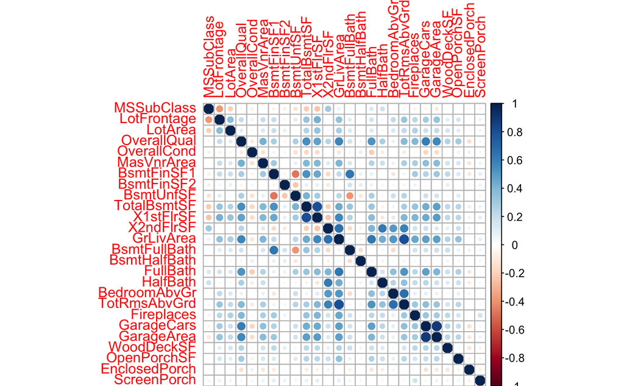

```r
library(corrplot)
numcorr=cor(trn_tst_numeric)
corrplot(numcorr)
```

Find variables of high correlation with each other (multicollinearity) and remove them. Use findCorrelation function from Caret package. All variables with more than 65% correlation are flagged and removed

```r
library(DMwR)
highcorvar=findCorrelation(numcorr,cutoff = 0.65)
# 4 Variables have high multicollinearity
names(trn_tst_numeric[,highcorvar])
```

```
[1] "GrLivArea"    "X1stFlrSF"    "GarageCars"   "TotRmsAbvGrd"
```

```r
trn_tst_numeric=trn_tst_numeric[,-highcorvar]
```

combine numeric, factor and date datasets back together using cbind, remove other datasets that are no longer needed

```r
train_test_mod=cbind(trn_test_dat,trn_tst_numeric,trn_tst_chr)
sum(is.na(train_test_mod))
```

```
[1] 0
```

```r
#no missing values
rm(trn_test_dat,trn_tst_chr,trn_tst_num,trn_tst_numeric,train_test,numcorr,highcorvar,imp_fctr,imp_num,YearBuilt)
```

```
object 'YearBuilt' not found
```

Separate out the train and test sets. Add the response variable ’SalePrice back to training dataset

```r
mod_train=train_test_mod[1:1460,]
mod_test=train_test_mod[1461:nrow(train_test_mod),]
mod_train$SalePrice=SalePrice
```

We now begin with the supervised machine learning tasks. Create a regression task.

```r
summary(mod_train$SalePrice)
```

```
   Min. 1st Qu.  Median    Mean 3rd Qu.    Max.
  34900  130000  163000  180900  214000  755000
```

```r
house_regr=makeRegrTask(data = mod_train,target = "SalePrice")
house_regr
```

```
Supervised task: mod_train
Type: regr
Target: SalePrice
Observations: 1460
Features:
numerics  factors  ordered
      28       38        0
Missings: FALSE
Has weights: FALSE
Has blocking: FALSE
```

Build a benchmark experiment for selecting the best learner (algorithm). List all learners that can perform regression learning on this task

```r
regr_learners=listLearners(house_regr)
```

[output not shown]

```r
house_learn=list( makeLearner("regr.gbm",fix.factors.prediction = TRUE),makeLearner("regr.rpart",fix.factors.prediction = TRUE),makeLearner("regr.randomForest",fix.factors.prediction = TRUE), makeLearner("regr.ksvm",fix.factors.prediction = TRUE), makeLearner("regr.nnet",fix.factors.prediction = TRUE))
house_learn
```

```
[[1]]
Learner regr.gbm from package gbm
Type: regr
Name: Gradient Boosting Machine; Short name: gbm
Class: regr.gbm
Properties: missings,numerics,factors,weights,featimp
Predict-Type: response
Hyperparameters: distribution=gaussian,keep.data=FALSE


[[2]]
Learner regr.rpart from package rpart
Type: regr
Name: Decision Tree; Short name: rpart
Class: regr.rpart
Properties: missings,numerics,factors,ordered,weights,featimp
Predict-Type: response
Hyperparameters: xval=0


[[3]]
Learner regr.randomForest from package randomForest
Type: regr
Name: Random Forest; Short name: rf
Class: regr.randomForest
Properties: numerics,factors,ordered,se,featimp
Predict-Type: response
Hyperparameters: se.method=bootstrap,se.boot=50,ntree.for.se=100


[[4]]
Learner regr.ksvm from package kernlab
Type: regr
Name: Support Vector Machines; Short name: ksvm
Class: regr.ksvm
Properties: numerics,factors
Predict-Type: response
Hyperparameters: fit=FALSE


[[5]]
Learner regr.nnet from package nnet
Type: regr
Name: Neural Network; Short name: nnet
Class: regr.nnet
Properties: numerics,factors,weights
Predict-Type: response
Hyperparameters: size=3
```

Set the resampling strategy- we use cross validation with 3 iterations

```r
house_resamp=makeResampleDesc(method = "CV",iters=3)
house_resamp
```

```
Resample description: cross-validation with 3 iterations.
Predict: test
Stratification: FALSE
```

list all measure that should be evaluated for selecting the best learner. We’ll use R Squared and MSE for evaluation purposes

```r
listMeasures(house_regr)
```

```
 [1] "rsq"         "rae"         "rmsle"       "mse"         "rrse"        "medse"       "mae"
 [8] "timeboth"    "timepredict" "medae"       "featperc"    "mape"        "rmse"        "sse"
[15] "arsq"        "expvar"      "msle"        "sae"         "timetrain"
```

```r
house_measures=list(mse,rsq)
house_measures
```

```
[[1]]
Name: Mean of squared errors
Performance measure: mse
Properties: regr,req.pred,req.truth
Minimize: TRUE
Best: 0; Worst: Inf
Aggregated by: test.mean
Note: Defined as: mean((response - truth)^2)

[[2]]
Name: Coefficient of determination
Performance measure: rsq
Properties: regr,req.pred,req.truth
Minimize: FALSE
Best: 1; Worst: -Inf
Aggregated by: test.mean
Note: Also called R-squared, which is 1 - residual_sum_of_squares / total_sum_of_squares.
```

Perform the benchmarking experiment to understand the best learners

```r
house_bench=benchmark(learners = house_learn,tasks = house_regr,resamplings = house_resamp,measures = house_measures)
```

```
Task: mod_train, Learner: regr.gbm
[Resample] cross-validation iter 1: mse.test.mean=6.53e+09,rsq.test.mean=0.0761
[Resample] cross-validation iter 2: mse.test.mean=5.28e+09,rsq.test.mean=0.083
[Resample] cross-validation iter 3: mse.test.mean=5.55e+09,rsq.test.mean=0.0886
[Resample] Aggr. Result: mse.test.mean=5.79e+09,rsq.test.mean=0.0826
Task: mod_train, Learner: regr.rpart
[Resample] cross-validation iter 1: mse.test.mean=2.42e+09,rsq.test.mean=0.658
[Resample] cross-validation iter 2: mse.test.mean=2.01e+09,rsq.test.mean=0.651
[Resample] cross-validation iter 3: mse.test.mean=1.73e+09,rsq.test.mean=0.715
[Resample] Aggr. Result: mse.test.mean=2.05e+09,rsq.test.mean=0.675
Task: mod_train, Learner: regr.randomForest
[Resample] cross-validation iter 1: mse.test.mean=1.28e+09,rsq.test.mean=0.818
[Resample] cross-validation iter 2: mse.test.mean=8.04e+08,rsq.test.mean=0.86
[Resample] cross-validation iter 3: mse.test.mean=7.66e+08,rsq.test.mean=0.874
[Resample] Aggr. Result: mse.test.mean=9.51e+08,rsq.test.mean=0.851
Task: mod_train, Learner: regr.ksvm
[Resample] cross-validation iter 1: mse.test.mean=1.39e+09,rsq.test.mean=0.803
[Resample] cross-validation iter 2: mse.test.mean=7.64e+08,rsq.test.mean=0.867
[Resample] cross-validation iter 3: mse.test.mean=8.07e+08,rsq.test.mean=0.867
[Resample] Aggr. Result: mse.test.mean=9.88e+08,rsq.test.mean=0.846
Task: mod_train, Learner: regr.nnet
[Resample] cross-validation iter 1:
```

```
mse.test.mean=7.08e+09,rsq.test.mean=-0.00151
[Resample] cross-validation iter 2:
```

```
mse.test.mean=5.66e+09,rsq.test.mean=0.0154
[Resample] cross-validation iter 3:
```

```
mse.test.mean=6.09e+09,rsq.test.mean=-4.33e-09
[Resample] Aggr. Result: mse.test.mean=6.28e+09,rsq.test.mean=0.00463
```

```r
house_bench
```

```
    task.id        learner.id mse.test.mean rsq.test.mean
1 mod_train          regr.gbm    5785052009   0.082588638
2 mod_train        regr.rpart    2053275502   0.674709011
3 mod_train regr.randomForest     951344238   0.850930549
4 mod_train         regr.ksvm     987861677   0.845886417
5 mod_train         regr.nnet    6277485427   0.004632742
```

```r
names(house_bench)
```

```
[1] "results"  "measures" "learners"
```

```r
house_bench$results
```

```
$mod_train
$mod_train$regr.gbm
Resample Result
Task: mod_train
Learner: regr.gbm
Aggr perf: mse.test.mean=5.79e+09,rsq.test.mean=0.0826
Runtime: 0.679489

$mod_train$regr.rpart
Resample Result
Task: mod_train
Learner: regr.rpart
Aggr perf: mse.test.mean=2.05e+09,rsq.test.mean=0.675
Runtime: 0.231517

$mod_train$regr.randomForest
Resample Result
Task: mod_train
Learner: regr.randomForest
Aggr perf: mse.test.mean=9.51e+08,rsq.test.mean=0.851
Runtime: 34.5214

$mod_train$regr.ksvm
Resample Result
Task: mod_train
Learner: regr.ksvm
Aggr perf: mse.test.mean=9.88e+08,rsq.test.mean=0.846
Runtime: 1.2698

$mod_train$regr.nnet
Resample Result
Task: mod_train
Learner: regr.nnet
Aggr perf: mse.test.mean=6.28e+09,rsq.test.mean=0.00463
Runtime: 0.709501
```

Visualize results of the benchmarking experiment

```r
bench_data=getBMRPerformances(house_bench,as.df = TRUE)
bench_data
```

| task.id | learner.id | iter | mse | rsq |
| --- | --- | --- | --- | --- |
| mod_train | regr.gbm | 1 | 6531773990 | 7.610537e-02 |
| mod_train | regr.gbm | 2 | 5275103533 | 8.304327e-02 |
| mod_train | regr.gbm | 3 | 5548278503 | 8.861727e-02 |
| mod_train | regr.rpart | 1 | 2417729600 | 6.580213e-01 |
| mod_train | regr.rpart | 2 | 2007936229 | 6.509660e-01 |
| mod_train | regr.rpart | 3 | 1734160676 | 7.151397e-01 |
| mod_train | regr.randomForest | 1 | 1283904480 | 8.183966e-01 |
| mod_train | regr.randomForest | 2 | 804052543 | 8.602338e-01 |
| mod_train | regr.randomForest | 3 | 766075692 | 8.741613e-01 |
| mod_train | regr.ksvm | 1 | 1392459398 | 8.030419e-01 |

[output cut: 5 more lines]

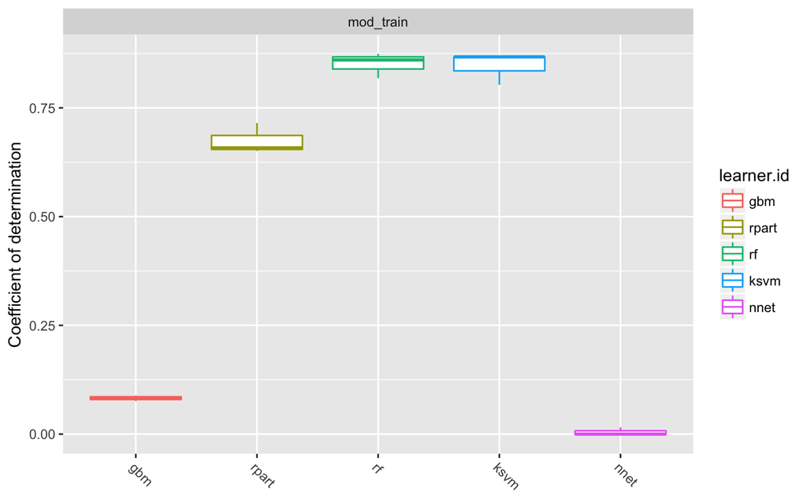

```r
plotBMRBoxplots(house_bench,measure = rsq)+aes(col=learner.id)
```

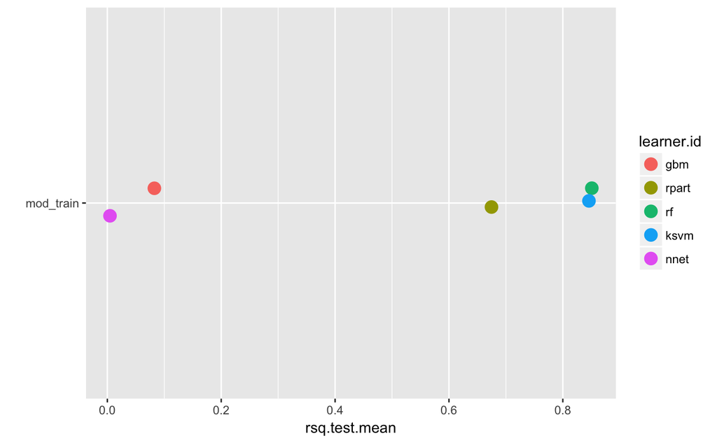

```r
plotBMRSummary(house_bench,measure = rsq)
```

clearly support vector machine (ksvm) and random forest are the best algorithms giving an rsquared values of almost 85%

```r
?randomForest
rf_learn=makeLearner("regr.randomForest",fix.factors.prediction = TRUE,ntree=2000)
#increase the number of iterations to 5, keep the resampling strategy as cross validation
rf_resamp=makeResampleDesc(method = "CV",iters=5)
rf_measures=list(mse,rsq)
house_trn1=mlr::train(learner = rf_learn,task = house_regr)
house_trn1
```

```
Model for learner.id=regr.randomForest; learner.class=regr.randomForest
Trained on: task.id = mod_train; obs = 1460; features = 66
Hyperparameters: se.method=bootstrap,se.boot=50,ntree.for.se=100,ntree=2e+03
```

Predict using the trained model using the new test dataset

```r
rf_predict1=predict(house_trn1,newdata = mod_test)
head(rf_predict1,20)
```

```
$predict.type
[1] "response"

$data
```

|  | response |
| --- | --- |
| 1461 | 133145.72 |
| 1462 | 156522.27 |
| 1463 | 177986.27 |
| 1464 | 184554.57 |
| 1465 | 200158.95 |
| 1466 | 188556.57 |
| 1467 | 181551.79 |
| 1468 | 177743.98 |
| 1469 | 180623.28 |
| 1470 | 128750.91 |

[output cut: 990 more lines]

```
$threshold
[1] NA

$task.desc
$id
[1] "mod_train"

$type
[1] "regr"

$target
[1] "SalePrice"

$size
[1] 1460

$n.feat
numerics  factors  ordered
      28       38        0

$has.missings
[1] FALSE

$has.weights
[1] FALSE

$has.blocking
[1] FALSE

attr(,"class")
[1] "TaskDescRegr"       "TaskDescSupervised" "TaskDesc"

$time
[1] 0.888

$error
[1] NA
```

```r
rf_predict1$data
```

|  | response |
| --- | --- |
| 1461 | 133145.72 |
| 1462 | 156522.27 |
| 1463 | 177986.27 |
| 1464 | 184554.57 |
| 1465 | 200158.95 |
| 1466 | 188556.57 |
| 1467 | 181551.79 |
| 1468 | 177743.98 |
| 1469 | 180623.28 |
| 1470 | 128750.91 |

[output cut: 990 more lines]

Make the first submission

```r
submit1=read_csv("sample_submission.csv")
submit1$SalePrice=NULL
submit1$SalePrice=rf_predict1$data$response
write.csv(submit1,"submit2.csv",row.names = FALSE)
```